# 230323 PanNET classifier ground truth

2023-04-20

# 1 Aim

In `230301_PanNET_classifier_tidymodels` some disagreement between the communities from consensus clustering and the PCA embeddings were observed.

Here alternative ways of constructing the ground truth are investigated. Additionally, the uncertainty of the consensus clustering is evaluated to highlight hard to classify samples.

# 2 Loading data

The 155 PanNET samples used to define the epigenetic groups are loaded as described in the `030_NETG1G2_EPIC` script `220609_NETG1G2_EPIC_consensus_clustering_plus_metastases`.

```
## using normalized data from current environment
```

```
## using ComBat data from current environment
```

# 3 Consensus clustering confidence

The result of consensus clustering is a matrix with a range 0f $[0;1]$. Higher values indicate that two samples are frequently found in the same cluster with 1 indicating a perfect match.

Large values outside of the cluster of interest indicate increased likelihood of a sample to associate with samples from other clusters. This can be useful to measure the uncertainty of cluster assignment in consensus clustering.

## 3.1 Consensus clustering heatmap

Consensus clustering was performed for 5 final clusters.

Evaluating the optimal number of clusters is complex and may require estimating a null model (see [Senbabaoglou, 2014](https://doi.org/10.1038/srep06207) and [John, 2020](https://doi.org/10.1038/s41598-020-58766-1))

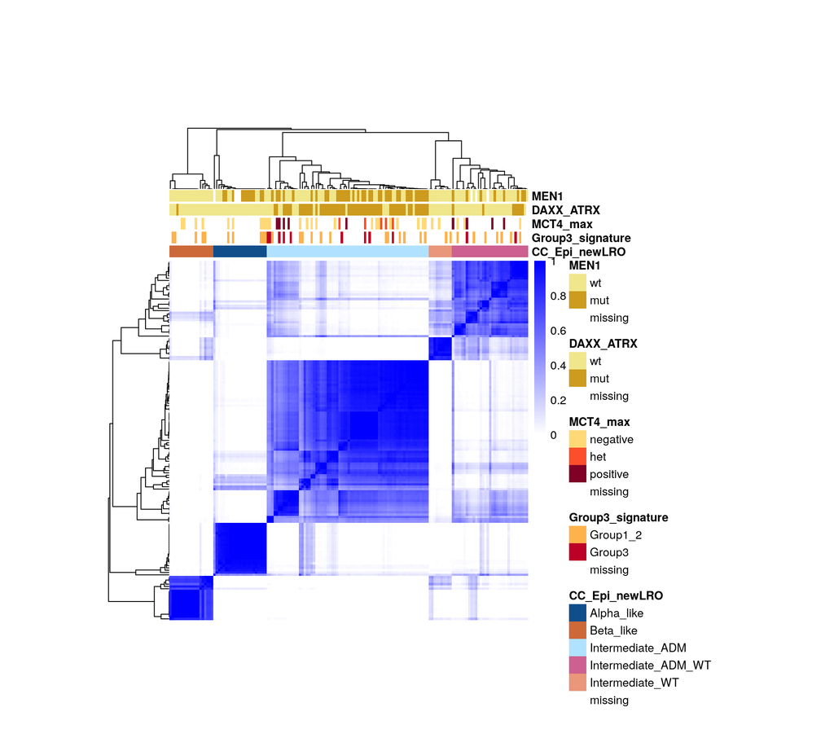

## 3.2 Entropy

Entropy measures how variable a distribution is. This can be applied to the consensus scores per sample. A low entropy indicates that the consensus values of a sample are limited to few values. This is the expected case for well clustered samples (all scores are close to 1). For less clearly defined clusters there are more different consensus values and as a result higher entropy.

Originally entropy is only defined for discrete variables. Here the entropy is computed by binning the continuous consensus score into 100 bins. There are more advanced techniques that calculate continuous entropy using integration or interpolation. In the future it may be best to replace the coarse binning approach with some of these techniques.

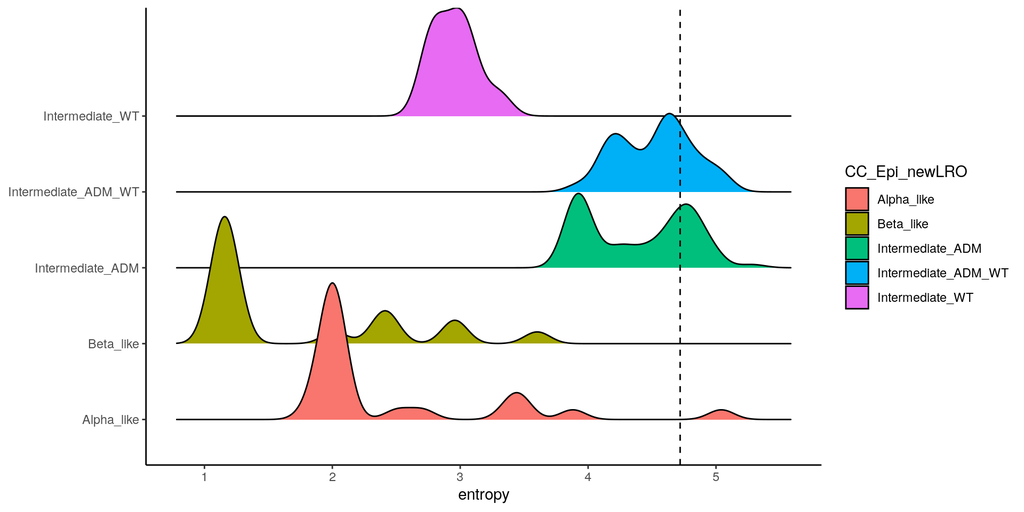

- Based on entropy the samples from Alpha- and Beta-like clusters have the lowest variability in consensus scores
- Both Alpha- and Beta-like groups have several outliers
- The entropy of the Intermediate groups generally is higher
- The vertical line indicates the 80th percentile (accuracy limit of the random forest classifier)

Overall the distribution of entropy matches well with the visual impression of the consensus matrix.

As an example, the consensus matrix for the cluster of Alpha-like cells is visualized ordered in ascending order of entropy.

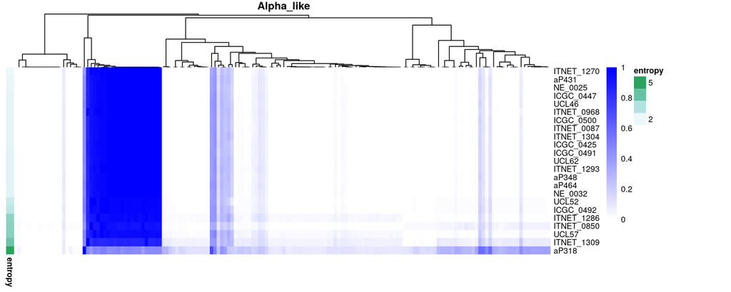

- With increasing entropy the uncertainty of consensus clustering increases

## 3.3 Mean consensus clustering scores

Alternatively, the consensus matrix can be summarized as the mean similarity scores within and without of the final cluster assignment.

### 3.3.1 Per cluster average

This gives an easy overview over the direction of misclassification.

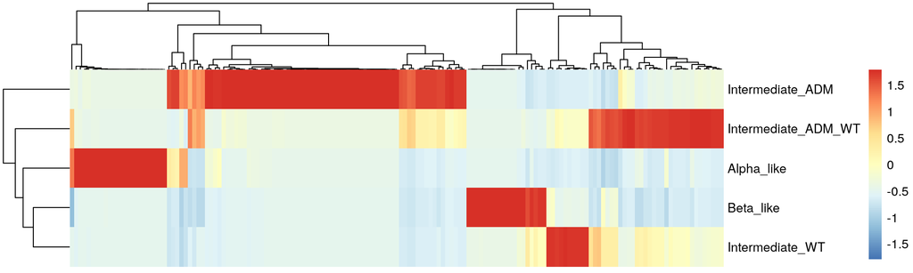

- The largest extent of uncertainty is between the Intermediate groups as expected

# 4 PCA

In the PCA projection based on the DMPs from Di Domenico 2020 the issues with consensus clustering were observed initially.

## 4.1 Normalized vs ComBat corrected

The consensus clustering was performed after ComBat correction of the `Slide` variable while the random forest is trained using the normalized data only. This was done because ComBat correction in the cross validation fold frequently would result in levels without replicates. Orphan samples will be normalized to the overall mean expression value potentially introducing artifacts.

When predicting unknown samples it also is not possible to apply batch correction because each sample is considered individually.

In Capper 2018 batch correction was performed between frozen and FFPE specimen. In this case new samples can be corrected because they belong to the groups present in the training data. For correction the coefficients of the linear model are extracted and applied to unknown data points.

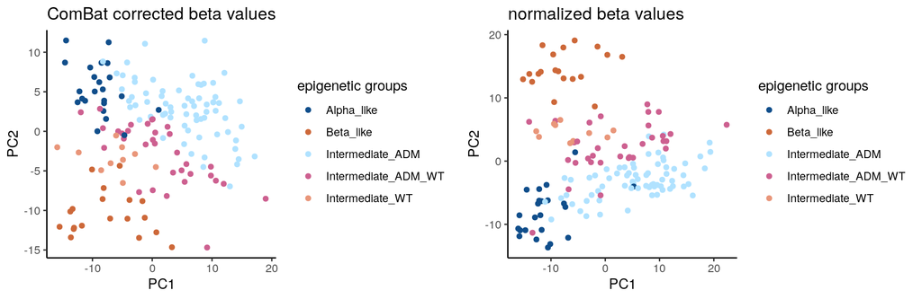

- The ComBat corrected data shows a more homogenous distribution of samples
- This makes it harder to discriminate between some groups

### 4.1.1 Association of Slide with PC dims

To test how much the Slide variable is associated with the principal components, `kruskal-wallis` p values are calculated for each PC. The dashed line indicates a p value of 0.05, the dotted line the bonferroni corrected p value cutoff.

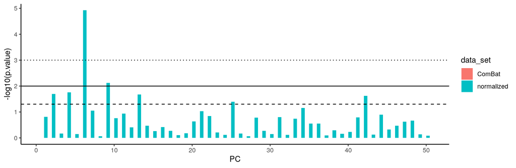

- In the normalized data the PC6 is clearly associated with the Slide variable
- As expected, in the ComBat corrected data the association is completely corrected

### 4.1.2 Relevant PC dimensions

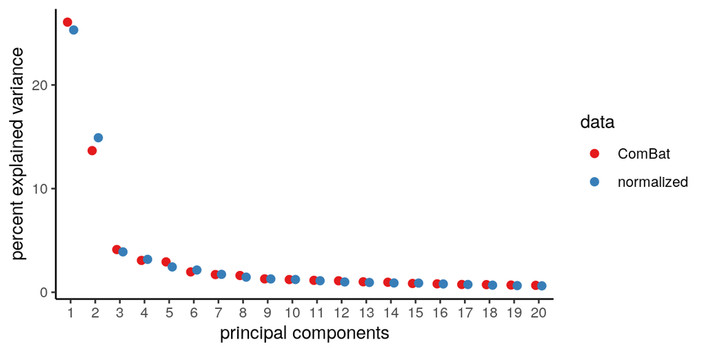

- In both data sets adding more than 10 principal components is not necessary
- A large part of the variance is already captured by 5 dimensions

### 4.1.3 Probability of finding associations

The estimated frequencies for association with p value < 0.05 is 0.0266. When using an Bonferroni adjusted p value < 0.05 the frequency is 0.0012.

This shows that more PCs are associated with the Slide variable than expected by chance.

**However, due to the problems with a Slide based batch correction in the later steps it would be best to identify clusters without this step. The resulting data needs to be checked for a link between the Slide variable and the assigned group to exclude technical artifacts during clustering.**

## 4.2 Known biological variables

Known biological variables are visualized in the PCA of the normalized values.

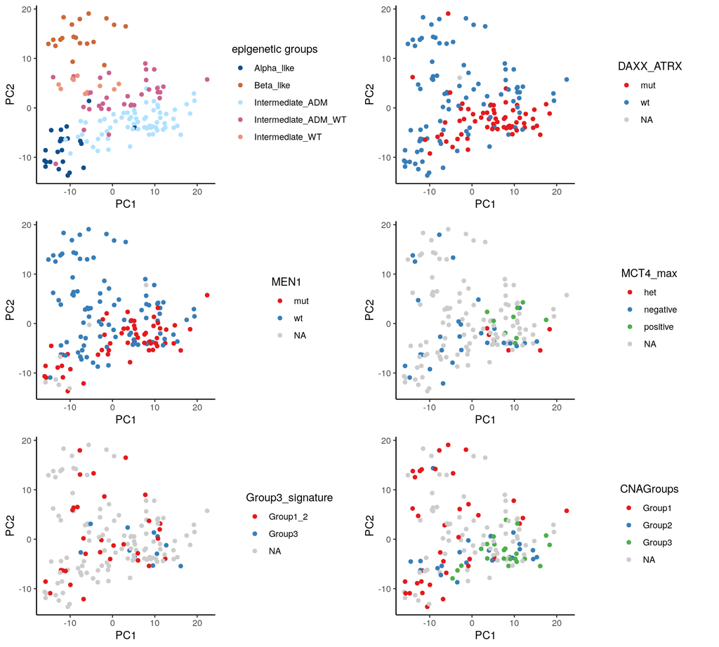

## 4.3 Entropy of the alpha-like cluster

To visualize uncertainty of assignment the entrop is used.

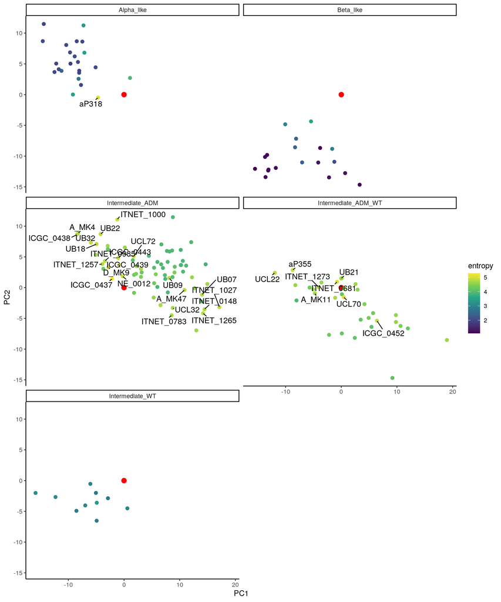

## 4.4 UMAP

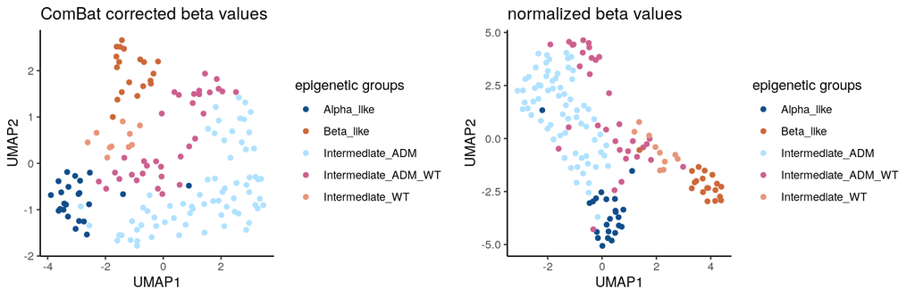

# 5 Random forest predictions

- Double negative vs double positive?
- How do the RF predictions look in the UMAP?

# 6 Next

PCA / UMAP on top n probes (how to select them?) The DMPs favor separation of Alpha_ and Beta_like but likely not discriminate the Intermediate cases

# 7 Redefining ground truth:

Hierarchical clustering seems to be not optimal for classification (many misclassifications in PCA)

Should the new G1G2 samples be added directly to the ground truth algorithm? The best way will be to define the ground truth algorithm using only the 155 samples When it is extended by the G1G2 samples, unstable candidates can be identified and reviewed

# 8 155 samples

All probes? (DMPs may be overfit but clearly delineate the alpha vs beta pheotype) feature selection PCA / non-linear embedding bootstrapping of embedding Silhouette scores of original embedding as measure? See single cell integration benchmarks DBSCAN / graph based clustering Based on the DMP umap DBSCAN may be problematic Repeat silhouette analysis on the bootstraps used before - show improvement over consensus clustering Intersection of poorly clustered samples and unstable samples in classification / consensus clustering manual review of edge cases (unclassified cases for DBSCAN) manual review of discrepancies between CC and new clustering

# 9 New samples:

Projection into PCA space / non-linear embedding clustering (including old samples?) manual review of altered classes Bootstrapping analysis?

Do all this before RF training to have a fixed ground truth and validation cohort

visualization of potential problems with batch correction:

[output not shown]

[output not shown]

[output not shown]

[output not shown]

[output not shown]

[output not shown]

[output not shown]

[output not shown]

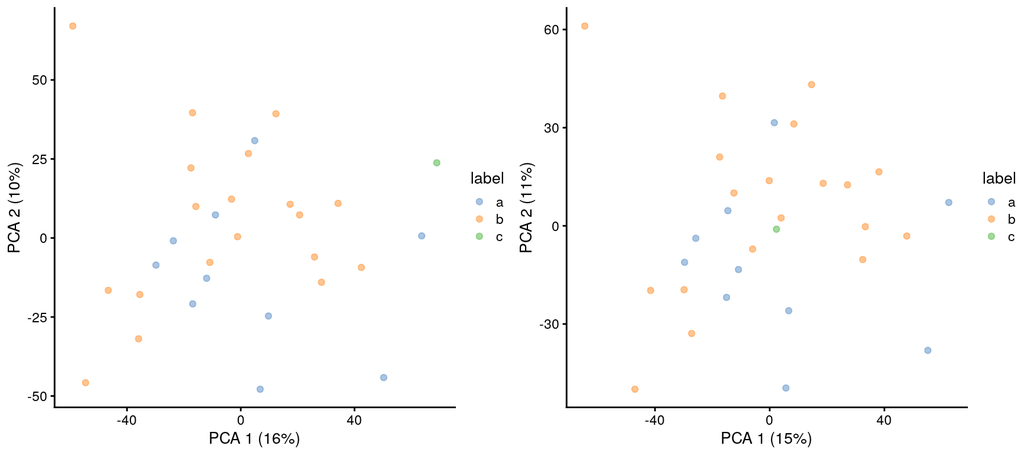